# Statistical Distributions

John

2019-07-05

## Distribution Exploration

Overview of major distributions and how to represent them with sample data.

[Good reference article](https://blog.cloudera.com/blog/2015/12/common-probability-distributions-the-data-scientists-crib-sheet/)

First, set some common distribution parameters that can be used across different examples:

### Parameters

```r
m <- 10 ## mean
s <- 2 ## std dev
nn <- 1000 ## number examples
pr <- 0.3 ## probability


set.seed(124)
```

*(not all distributions use all parameters and not all parameters are used by more than 1 distribution)*

### Normal

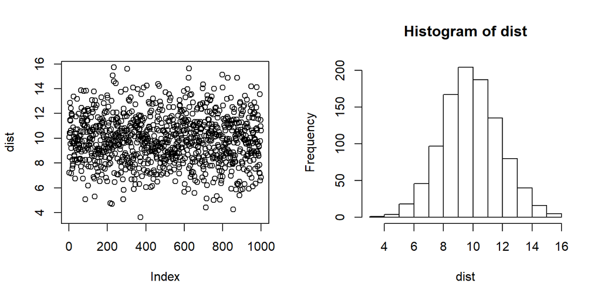

```r
## generate distribution sample
dname <- 'normal'
## set distribution parameters
dist <- rnorm(mean=m, sd=s, n=nn)

## set chart arrangement
par(mfrow=(c(1,2)))
## show data and histogram
plot(dist)
hist(dist)
```

```r
## convert to data frame (done in hidden code chunks for subsequent distribution data)
df.dist <- data.frame(distribution=dname,
                      values=dist)
## set up data frame to collect all the distributions
df.dist.all <- df.dist
## create columnar data with distribution name
df.dist.col <- df.dist %>% select(values) %>% rename(
  !!dname:=values
)
## set up data frame to collect columnar data for all data frames
df.dist.all.cols <- df.dist.col
```

### Uniform

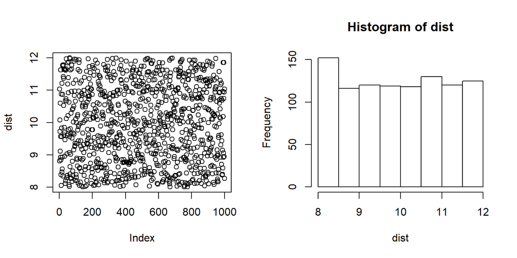

```r
## generate distribution sample
dname <- 'uniform'

## set distribution parameters
dist <- runif(n=nn, min=m-s, max=m+s)
## set chart arrangement
par(mfrow=(c(1,2)))
## show data and histogram
plot(dist)
hist(dist)
```

### Binomial

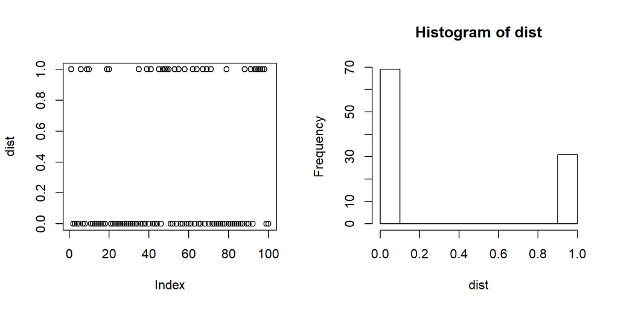

```r
## generate distribution sample
dname <- 'binomial'

## set distribution parameters
## decrease nn because need only small number to show binomial
## and with more it stretches y-axis when comparing
dist <- rbinom(n=nn/10, size=1, prob = pr)
## set chart arrangement
par(mfrow=(c(1,2)))
## show data and histogram
plot(dist)
hist(dist)
```

### Poisson

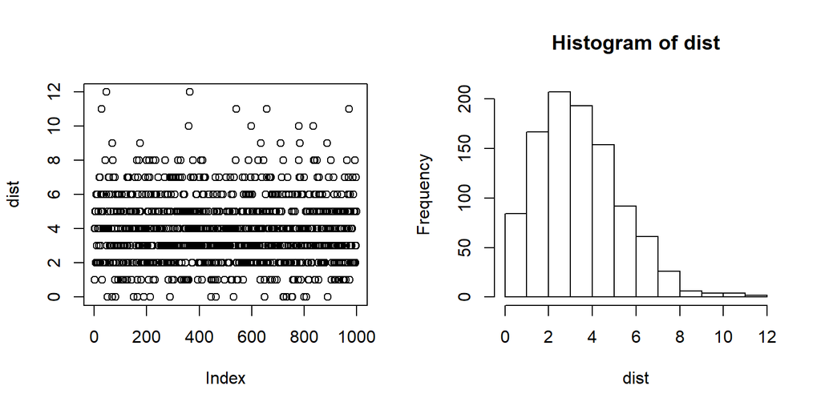

```r
## generate distribution sample
dname <- 'poisson'
lam <- 4
## set distribution parameters
dist <- rpois(lambda=lam, n=nn)
## set chart arrangement
par(mfrow=(c(1,2)))
## show data and histogram
plot(dist)
hist(dist)
```

- Poisson moves toward normal as lambda increases
- Poisson is a discrete distribution, which I believe is what can account for gaps in the histogram bars

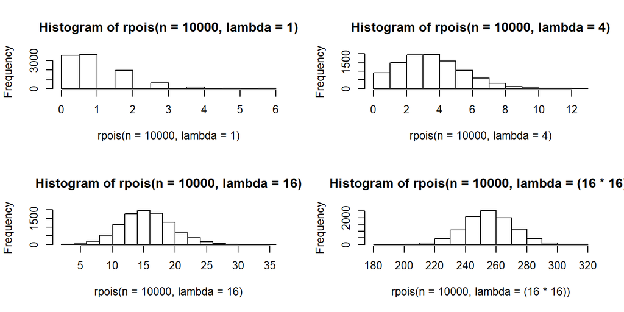

```r
par(mfrow=c(2,2))
hist(rpois(n=10000, lambda = 1))
hist(rpois(n=10000, lambda = 4))
hist(rpois(n=10000, lambda = 16))
hist(rpois(n=10000, lambda = (16*16)))
```

So how to use a Poisson distribution to simulate skewed data, if the mean is large?

- Set the lambda low and then scale it up by multiplying the distribution

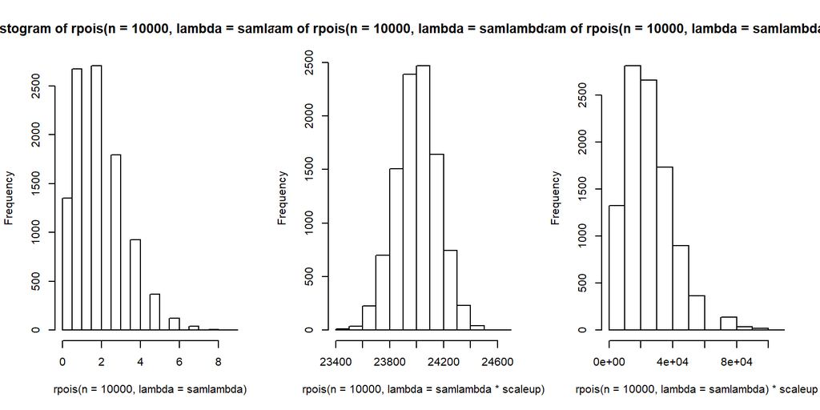

```r
## to simulate data set with high mean
scaleup <- 12000
samlambda <- 2
par(mfrow=c(1,3))
hist(rpois(n=10000, lambda = samlambda))
hist(rpois(n=10000, lambda=samlambda*scaleup))
hist(rpois(n=10000, lambda = samlambda)*scaleup)
```

### Summary

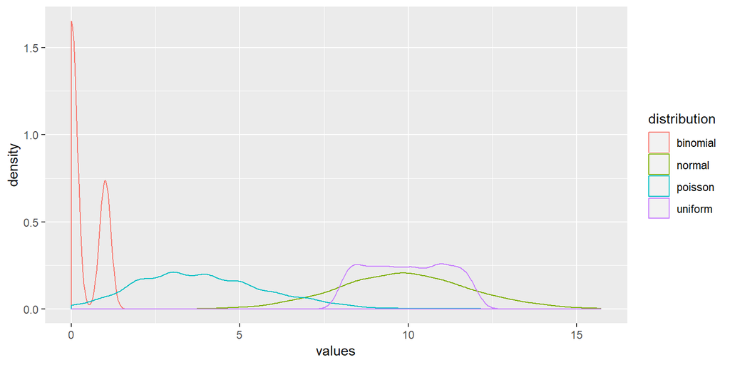

```r
ggplot(df.dist.all, aes(x=values, color=distribution))+geom_density()
```

## Normality Testing

### Visually

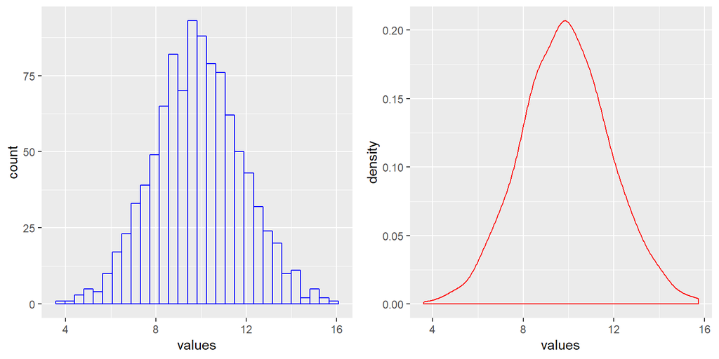

```r
df.norm <- df.dist.all %>% filter(distribution=='normal')

h <- ggplot(df.norm, aes(x=values))+geom_histogram(fill=NA, color='blue')

cd <-
ggplot(df.norm, aes(x=values))+geom_density(color='red')

grid.arrange(h, cd, nrow=1)
```

…or better yet: overlay density of sample data with ideal normal curve for same mean and sd

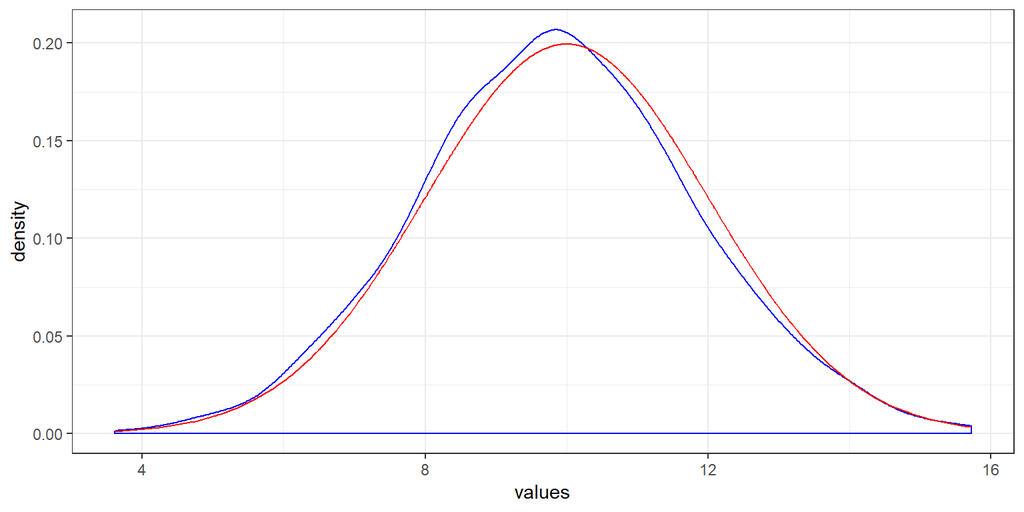

```r
df.norm <- df.norm %>%
  mutate(normprob=dnorm(values, mean=m, sd=s))

ggplot(df.norm, aes(x=values))+geom_density(color='blue')+
  geom_line(aes(x=values, y=normprob), color='red')+theme_bw()
```

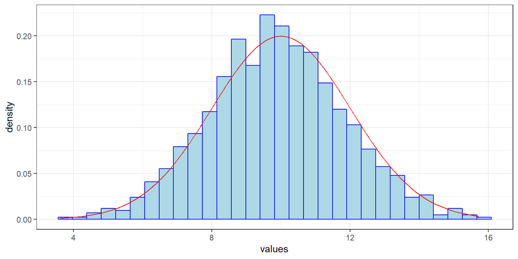

```r
ggplot(df.norm, aes(x=values))+geom_histogram(aes(y=..density..), fill='lightblue', color='blue')+
  geom_line(aes(x=values, y=normprob), color='red')+theme_bw()
```

### Q-Q (quantile-quantile) plot

- shows correlation of data with theoretical normal distribution
- provides 45-degree line for reference: the more the points align with the line the more normal the distribution of the data is
- can use ggplot but the ggpubr pkg is even handier (and shows confidence interval)

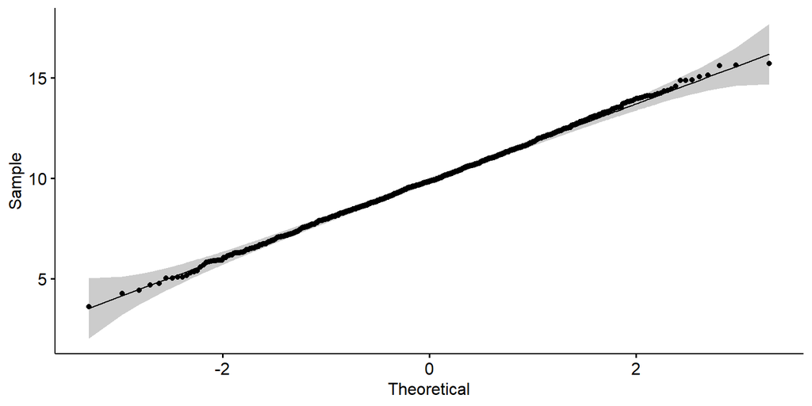

```r
library(ggpubr)
ggqqplot(df.norm$values)
```

Pretty tight - looks normal!

### Statistically

```r
## from: http://www.sthda.com/english/wiki/normality-test-in-r
shapiro.test(df.norm$values)
```

```
##
##  Shapiro-Wilk normality test
##
## data:  df.norm$values
## W = 0.99916, p-value = 0.941
```

Null hypothesis: the data are not significantly different from normal. If there’s a low p-value can we reject the null hypothesis, and consider the data to NOT follow a normal distribution.

In this case, high p-value confirms null hypothesis that the data fits normal distribution. Relax…it’s normal!

### With other distributions

#### Poisson

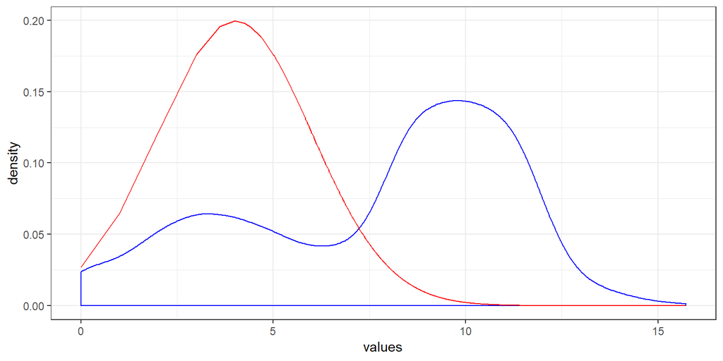

```r
df.poisson <- df.dist.all %>% mutate(normprob=dnorm(values, mean=lam, sd=s))

ggplot(df.poisson, aes(x=values))+geom_density(color='blue')+
  geom_line(aes(x=values, y=normprob), color='red')+theme_bw()
```

```r
shapiro.test(df.poisson$values)
```

```
##
##  Shapiro-Wilk normality test
##
## data:  df.poisson$values
## W = 0.93359, p-value < 2.2e-16
```

Comparing Poisson distributions with different levels of lambda

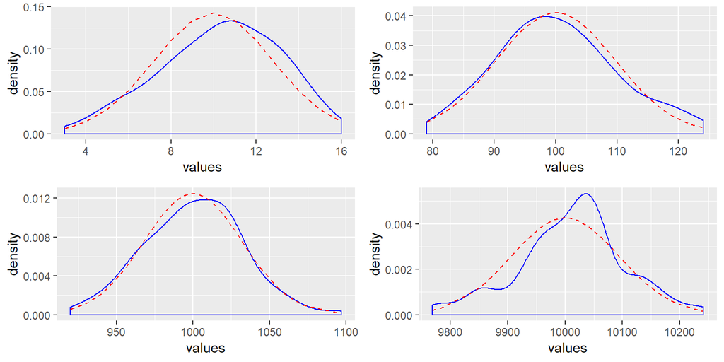

```r
df.pois.all <- data.frame()
for(i in 1:4){
  lam <- 10^i
  examplelam <- paste0('example',lam)
  pois <- rpois(n=100, lambda = lam)
  df.pois <- data.frame(example=examplelam,
                        values=pois)
  df.pois <- df.pois %>% mutate(
    normprob=dnorm(values, mean=lam, sd=sd(df.pois$values))
  )
  df.pois.all <- bind_rows(df.pois.all, df.pois)
}
## function for generating plots of all four variations
plotGen <- function(data, enum){
  data <- data %>% filter(example==paste0('example',enum))
  ggplot(data, aes(x=values))+geom_density(color='blue')+
    geom_line(aes(y=normprob), color='red', linetype='dashed')
}
## use function to generate plots for each variation
pp100 <- plotGen(df.pois.all, 10)
pp200 <- plotGen(df.pois.all, 100)
pp300 <- plotGen(df.pois.all, 1000)
pp400 <- plotGen(df.pois.all, 10000)
## display plots in grid
grid.arrange(pp100, pp200, pp300, pp400, nrow=2)
```